# Blinder Würfel

# Binomialverteilung

Die Binomialverteilung gibt Wahrscheinlichkeiten für eine bestimmte Anzahl des Auftretens eines Ereignisses bei einem Bernoulliexperiment.

Zunächst ist zu klären, ob es sich um ein Bernoullie-Experiment handelt: Es werden zwei Ereignisse definiert, das “Würfeln einer Augenzahl” und das “Würfeln der leeren Seite”. Die Wahrscheinlichkeit, daß eine Zahl gewürfelt wird, ist p = 1/6, das Würfeln einer leeren Seite ist ( 1-p) = 5/6. Die Wahrscheinlichkeit ist bei jedem Wurf gleich, und die Ergebnisse der Würfe sind unabhängig voneinander, schließlich hat der Würfel kein Gedächtnis. Es handelt sich also um ein Bernoullie-Experiment.

Die Formel:

$$\binom{n}{k} p^k (1-p)^{n-k}$$

P(y=0)

Die Wahrscheinlichkeit, daß einer leeren Seite gewürfelt wird, ist p = 5/6, das Würfeln eine Zahl ( 1-p) = 1/6 und dann müssen wir 6-elementigen Teilmengen einer 6-elementigen Menge multiplizieren.

$$P(y=0)=\binom{6}{6}\frac{5^6}{6^6}.\frac{1^0}{6^0}
=0.334$$

```r
dbinom(6,6,5/6)
```

```
## [1] 0.334898
```

P(y=1)

```r
dbinom(1,6,1/6)
```

```
## [1] 0.4018776
```

P(y=2)

```r
dbinom(1,6,1/6)
```

```
## [1] 0.4018776
```

Nach der Simulation stimmen P(y=2) und P(y=1) überein.

P(y=21)

Die Augensumme (y=21) , wenn man nacheinander sechs, fünf, vier, drei, zwei, eins würfelt. Die Wahrscheinlichkeit eine 2 zu würfeln, p = 1/6, die eine 0 zu würfeln (1-p) = 5/6.

Dann müssen wir 6-elementigen Teilmengen einer 6-elementigen Menge multiplizieren.

$$P(y=21)=\binom{6}{1}\frac{1^6}{6^6}.\frac{5^0}{6^0}=2.143e^-5$$

```r
dbinom(6,6,1/6)
```

```
## [1] 2.143347e-05
```

# Diagramm Relative Häufigkeit

In diesem Diagramm wollen wir die relative Häufigkeit der Augensumme für 0 bis 21 darstellen.

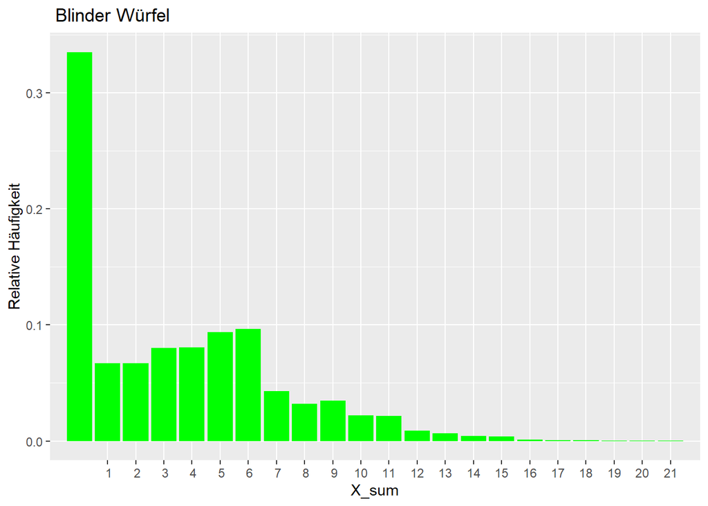

```r
tabelle<- data.frame (y_i=seq(1, n_rep, by=1))
tabelle$y_i<-x_sum

diagramm<-ggplot(tabelle) +
           geom_bar(mapping=aes(x=y_i ,y = ..prop..),
                    fill="green")+ scale_x_discrete(limits=c(1,2,3,4,5,6,7,8,9,10,11,12,13,14,15,16,17,18,19,20,21)) +
  labs(
    title=" Blinder Würfel",
    x="X_sum",
    y="Relative Häufigkeit"
  )
diagramm
```

```r
table( x_sum)
```

```
## x_sum
##       0       1       2       3       4       5       6       7       8       9
## 1005399  200573  200733  240700  241726  281363  290229  128282   96542  104346
##      10      11      12      13      14      15      16      17      18      19
##   65939   65205   27298   19195   12859   11528    3570    1874    1887     322
##      20      21
##     363      67
```